# Predicting Turnover Rate for NYPD

### Using NYC OpenData and Crime Statistics

#### By Bethan Cordone and Itzel Melgoza

## Introduction

Turnover rate refers to the rate at which employees leave a company or organization in a specified interval of time. A high turnover rate can prove costly to the company or institution as it will entail more frequent training of incoming workers. The NYC Citywide Payroll Data published on NYC OpenData contains payroll information for all municipal workers from the years 2014 to 2021. Given that the data provides information on an employee's start date as well as whether they are still actively working with an agency, we aimed to use this dataset to predict whether someone will stop working for an agency after 2 years. We were particularly interested in the effect of work location borough on predicting whether an employee stays on for more than 2 years. We decided to focus on the police department. Police departments characteristically have relatively low turnover rates with a national total turnover rate of 11% in the early 2000s (Wareham, 2015). Turnover rates were found to be highest in municipal agencies and rural areas. Through our data exploration, we explored how turnover rates in New York compare to the national average. In this project, we aim to predict whether someone will stop working for the police department after 2 years. We also explored patterns associated with our predictor variables and turnover rates.

We also created new features for our data set in an attempt to find new patterns and better predict turnover rates. We added features relating to crime rates and a feature relating to the percentage of leadership positions out of total positions. These attempted to answer the question of whether increasing crime rates affected turnover and if the percentage of leadership positions affected turnover.

```r
# packages used
library(lubridate)
library(dplyr)
library(ggplot2)
```

## A Description of the NYC OpenData

The columns in the dataset include fiscal year, payroll number, agency name, last name, first name, middle initial, agency start date, work location borough, title description, leave status as of June 30th, base salary, pay basis, regular hours, regular gross paid, overtime hours, total overtime paid, and total other pay. Each row represents a city employee's salary per fiscal year. The data has 4,496,767 entries with the 17 columns listed above. The columns are explored and cleaned in the sections below.

```r
df <- read.csv("Citywide_Payroll_Data__Fiscal_Year.csv")
```

```r
dim(df)
df[1:6, 1:3]
```

1. 4496767

2. 17

| Fiscal.Year | Payroll.Number | Agency.Name |
| --- | --- | --- |
| 2020 | 17 | OFFICE OF EMERGENCY MANAGEMENT |
| 2020 | 17 | OFFICE OF EMERGENCY MANAGEMENT |
| 2020 | 17 | OFFICE OF EMERGENCY MANAGEMENT |
| 2020 | 17 | OFFICE OF EMERGENCY MANAGEMENT |
| 2020 | 17 | OFFICE OF EMERGENCY MANAGEMENT |
| 2020 | 17 | OFFICE OF EMERGENCY MANAGEMENT |

```r
names(df)
```

1. 'Fiscal.Year'

2. 'Payroll.Number'

3. 'Agency.Name'

4. 'Last.Name'

5. 'First.Name'

6. 'Mid.Init'

7. 'Agency.Start.Date'

8. 'Work.Location.Borough'

9. 'Title.Description'

10. 'Leave.Status.as.of.June.30'

11. 'Base.Salary'

12. 'Pay.Basis'

13. 'Regular.Hours'

14. 'Regular.Gross.Paid'

15. 'OT.Hours'

16. 'Total.OT.Paid'

17. 'Total.Other.Pay'

## Date Exploration

We're interested in observing whether someone will stop working for an agency after 2 years. We first took a look at the start dates and the range of fiscal years.

```r
range(df$Fiscal.Year)
```

1. 2014

2. 2021

There is data for the fiscal years of 2014-2021. We observed that there were some data quality issues regarding the start dates, so we will aim to remove start dates that are beyond 2021 and substitute values that correspond to "" with NA. This is accomplished through the code below.

```r
# replace the "" dates with NA values
sum(df$Agency.Start.Date == "")
df$Agency.Start.Date[which(df$Agency.Start.Date == "")] <- NA
sum(df$Agency.Start.Date == "", na.rm=T)
```

63

0

```r
# the code below finds and replaces the erroneous dates with NA values
sum(df$Agency.Start.Date == "12/31/9999", na.rm = T)
sum(df$Agency.Start.Date > "12/31/2021", na.rm = T)
df$Agency.Start.Date[which(df$Agency.Start.Date =="12/31/9999")] <- NA
sum(df$Agency.Start.Date =="12/31/9999", na.rm=T)
```

415

0

0

```r
# this finds the entries that only have year values out of range and removes them
just_year <- substr(df$Agency.Start.Date, 7,10)
just_year <- as.numeric(just_year)
range(just_year,na.rm = TRUE)
sum(just_year > 2021, na.rm=T)

# convert the date using the lubricate package
date_col <- df$Agency.Start.Date %>% mdy
range(date_col, na.rm=T)
```

1. 1901

2. 2049

1

1. 1901-01-01

2. 2049-10-16

```r
# there is only one year out of range
just_year[which(just_year > 2021)]
just_year[which(just_year < 1950)]

early_rows <- df %>% filter(grepl('1901', Agency.Start.Date))
early_rows[1:6,1:6]
```

2049

1. 1901

2. 1901

3. 1948

4. 1946

5. 1949

6. 1948

7. 1945

8. 1945

9. 1901

10. 1901

11. 1946

12. 1948

13. 1948

14. 1901

15. 1901

16. 1901

17. 1901

| Fiscal.Year | Payroll.Number | Agency.Name | Last.Name | First.Name | Mid.Init |
| --- | --- | --- | --- | --- | --- |
| 2020 | 742 | DEPT OF ED PEDAGOGICAL | STREKO | DAVID | M |
| 2015 | NA | DEPT OF ED PEDAGOGICAL | STREKO | DAVID | M |
| 2014 | 742 | DEPT OF ED PEDAGOGICAL | STREKO | DAVID | M |
| 2014 | 742 | DEPT OF ED PEDAGOGICAL | PERFETTO | LORRAINE | M |
| 2017 | NA | DEPT OF ED PEDAGOGICAL | STREKO | DAVID | M |
| 2018 | 742 | DEPT OF ED PEDAGOGICAL | STREKO | DAVID | M |

By parsing through the different years in the start dates, we observed that there was one date which remained beyond 2021. This data corresponded to "10/16/2049" and we decided to remove this row from the dataset. There were also start dates for 1901 for two different individuals. This seemed unusual as they were still active in 2014 which would imply a abnormally long career. Both of these individuals were in the Dept of Ed Pedagogical and we decided to keep them in the data set and consider their removal if we decided to focus on this agency for the remainder of the project.

```r
# remove 2049 data point
df <- df[-which(df$Agency.Start.Date=="10/16/2049"),]
dim(df)
```

1. 4496766

2. 17

```r
# check that the dates have the desired range
df$Agency.Start.Date <- df$Agency.Start.Date %>% mdy
range(df$Agency.Start.Date, na.rm=T)
```

1. 1901-01-01

2. 2021-07-01

## Exploring Leave Status

```r
table(df$Leave.Status.as.of.June.30)
```

```
             ACTIVE              CEASED            ON LEAVE ON SEPARATION LEAVE
            3828710              574694               48368                7649
           SEASONAL
              37345
```

An employee can be deemed as either active, ceased, on leave, on separation leave, or seasonal. Given that ceased is the only label which clearly demonstrates that the employee has stopped working with a particular agency, we decided to treat any employee that does not have the leave status of "CEASED" as someone who is still a NYC government employee.

## Identifing Rows

Each row corresponds to a city employee salary per fiscal year, we wanted to observe how the data set accounts for data for the same employee. We can consider examples for an employee that is active in fiscal year 2021.

```r
active_employees <- df %>% filter((Fiscal.Year == "2021") &
                                    (Leave.Status.as.of.June.30 != "CEASED"))
ceased_employees <- df %>% filter((Fiscal.Year == "2021") &
                                    (Leave.Status.as.of.June.30 == "CEASED"))
```

```r
active_employees[1:3,1:6]
ceased_employees[1:3,1:6]
```

| Fiscal.Year | Payroll.Number | Agency.Name | Last.Name | First.Name | Mid.Init |
| --- | --- | --- | --- | --- | --- |
| 2021 | 996 | NYC HOUSING AUTHORITY | MUSTACIUOLO | VITO | J |
| 2021 | 996 | NYC HOUSING AUTHORITY | RUSS | GREGORY | P |
| 2021 | 816 | DEPT OF HEALTH/MENTAL HYGIENE | MCGROARTY | MICHAEL |  |

| Fiscal.Year | Payroll.Number | Agency.Name | Last.Name | First.Name | Mid.Init |
| --- | --- | --- | --- | --- | --- |
| 2021 | 462 | GUTTMAN COMMUNITY COLLEGE | EVENBECK | SCOTT | E |
| 2021 | 56 | POLICE DEPARTMENT |  |  |  |
| 2021 | 464 | COMMUNITY COLLEGE (QUEENSBORO) | ZINS | ROSEMARY | S |

```r
active_employee <- df %>%
  filter(Last.Name == "MUSTACIUOLO" & First.Name=="VITO" & Mid.Init =="J")
dim(active_employee)
active_employee <- active_employee %>%
  select(Fiscal.Year, Agency.Name, Agency.Start.Date, Work.Location.Borough,
         Title.Description, Leave.Status.as.of.June.30)
head(active_employee,10)
```

1. 10

2. 17

| Fiscal.Year | Agency.Name | Agency.Start.Date | Work.Location.Borough | Title.Description | Leave.Status.as.of.June.30 |
| --- | --- | --- | --- | --- | --- |
| 2020 | NYC HOUSING AUTHORITY | 2018-02-26 | MANHATTAN | EXECUTIVE DIRECTOR | ACTIVE |
| 2016 | HOUSING PRESERVATION & DVLPMNT | 1989-07-31 | MANHATTAN | DEPUTY COMMISSIONER | ACTIVE |
| 2015 | HOUSING PRESERVATION & DVLPMNT | 1989-07-31 | MANHATTAN | DEPUTY COMMISSIONER | ACTIVE |
| 2014 | HOUSING PRESERVATION & DVLPMNT | 1989-07-31 |  | DEPUTY COMMISSIONER | ACTIVE |
| 2017 | HOUSING PRESERVATION & DVLPMNT | 1989-07-31 | MANHATTAN | DEPUTY COMMISSIONER | ACTIVE |
| 2018 | HOUSING PRESERVATION & DVLPMNT | 1989-07-31 | MANHATTAN | DEPUTY COMMISSIONER | CEASED |
| 2018 | NYC HOUSING AUTHORITY | 2018-02-26 | MANHATTAN | EXECUTIVE DIRECTOR | ACTIVE |
| 2019 | HOUSING PRESERVATION & DVLPMNT | 1989-07-31 | MANHATTAN | DEPUTY COMMISSIONER | CEASED |
| 2019 | NYC HOUSING AUTHORITY | 2018-02-26 | MANHATTAN | EXECUTIVE DIRECTOR | ACTIVE |
| 2021 | NYC HOUSING AUTHORITY | 2018-02-26 | MANHATTAN | EXECUTIVE DIRECTOR | ACTIVE |

Using an employee who is active in 2021 as an example, we can see that we should have data for that employee for each year if they started working before or during 2014. Also, this example demonstrates that the dataset records whether an employee has moved to another agency. For this particular employee they were first ceased in the year 2018 and took on a new position in the year 2018 as well. Therefore multiple records can be found for this employee for the years 2018 and 2019 as it records the employee's ceased status at their previous agency and their active status at their current agency. This example employee alone demonstrates that their is some nuance related to how an employee's work history is recorded across agencies. As we observed that employees who have been "ceased" can reappear if they take on another job with the city in a different agency, it will be most useful to focus on a specific agency when trying to predict if an employee stops working after 2 years.

## Data Exploration of the "POLICE DEPARTMENT"

```r
head(table(df$Agency.Name)[order(table(df$Agency.Name), decreasing=T)],10)
```

```
        DEPT OF ED PEDAGOGICAL DEPT OF ED PER SESSION TEACHER
                        871883                         710893
             POLICE DEPARTMENT  DEPT OF ED PARA PROFESSIONALS
                        426753                         284663
BOARD OF ELECTION POLL WORKERS  DEPT OF ED HRLY SUPPORT STAFF
                        278852                         182631
               FIRE DEPARTMENT  DEPARTMENT OF EDUCATION ADMIN
                        147868                         128233
    DEPT OF PARKS & RECREATION    HRA/DEPT OF SOCIAL SERVICES
                        127626                         117632
```

```r
#the police department
pol_dept <- df %>% filter(Agency.Name=="POLICE DEPARTMENT")
```

As the title that an employee holds within their agency can lead to variations in their pay, it is necessary to work with an agency that has a variety of job titles with a substantial number of employees with that title.

```r
# job titles within police department
head(table(pol_dept$Title.Description)[order(table(pol_dept$Title.Description),
                                             decreasing=T)],10)
```

```
                  POLICE OFFICER              SCHOOL SAFETY AGENT
                          182162                            40123
                 P.O. DA DET GR3            SCHOOL CROSSING GUARD
                           24585                            19526
                       SERGEANT-        TRAFFIC ENFORCEMENT AGENT
                           16928                            15217
                        SERGEANT                       LIEUTENANT
                           14146                            11355
POLICE COMMUNICATIONS TECHNICIAN       POLICE ADMINISTRATIVE AIDE
                           11208                            10246
```

```r
range(pol_dept$Fiscal.Year)
range(pol_dept$Agency.Start.Date, na.rm=T)
range(pol_dept$Base.Salary)
```

1. 2015

2. 2021

1. 1960-11-14

2. 2021-06-11

1. 9.98

2. 243171

```r
top_ten_titles_pol <- names(head(table(pol_dept$Title.Description)
                                 [order(table(pol_dept$Title.Description),
                                        decreasing=T)],10))
top_ten_subset_pol <- pol_dept %>% filter(Title.Description %in% top_ten_titles_pol)
dim(top_ten_subset_pol)
nrow(pol_dept)
(nrow(top_ten_subset_pol)/nrow(pol_dept))*100
```

1. 345496

2. 17

426753

80.9592434030927

Employees that have a job title that is in the top 10 of job titles account for 81% of employees in the police department

```r
unique(top_ten_subset_pol$Work.Location.Borough)
```

1. MANHATTAN

2. QUEENS

3. BRONX

4. BROOKLYN

5. RICHMOND

**Levels**:**

1. ''

2. 'ALBANY'

3. 'Bronx'

4. 'BRONX'

5. 'BROOKLYN'

6. 'DELAWARE'

7. 'DUTCHESS'

8. 'GREENE'

9. 'Manhattan'

10. 'MANHATTAN'

11. 'NASSAU'

12. 'ORANGE'

13. 'OTHER'

14. 'PUTNAM'

15. 'Queens'

16. 'QUEENS'

17. 'Richmond'

18. 'RICHMOND'

19. 'SCHOHARIE'

20. 'SULLIVAN'

21. 'ULSTER'

22. 'WASHINGTON DC'

23. 'WESTCHESTER'

Given that the police department contains records for employees from different boroughs, this agency will allow us to explore how predicted turnover rate varies across boroughs.

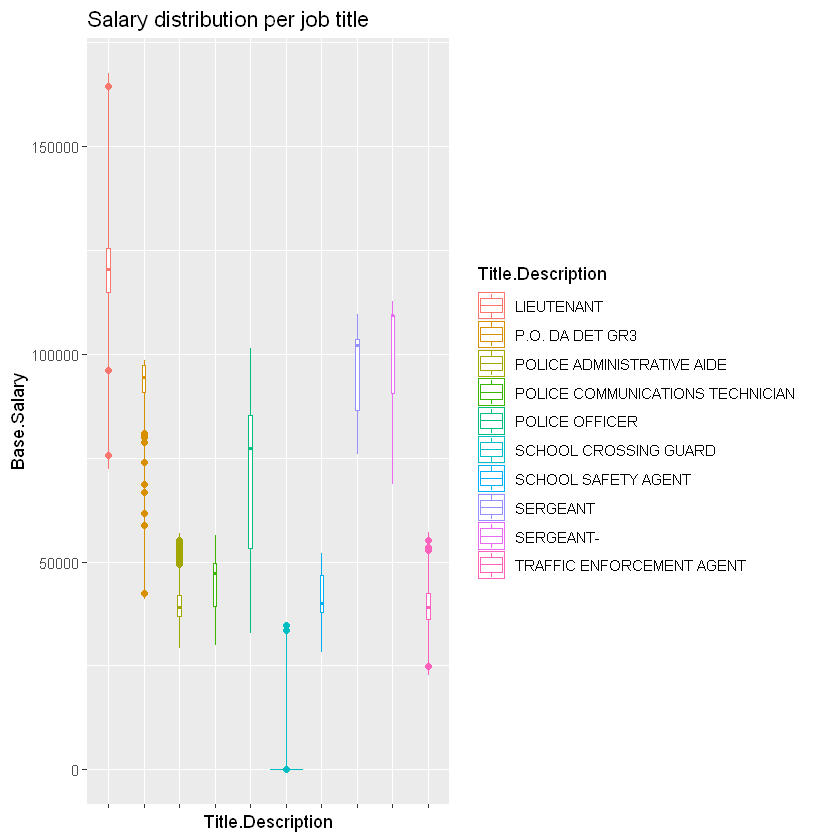

```r
vio_plot <-ggplot(top_ten_subset_pol, aes(x=Title.Description,
                                   y=Base.Salary, color=Title.Description)) +
  geom_violin(trim=FALSE)
vio_plot + geom_boxplot(width=0.1) + ggtitle("Salary distribution per job title") + theme(axis.text.x=element_blank())
```

There appear to be significant differences in mean base salary across job titles, but we were surprised to see a lack of a distribution of salaries for each job description.

```r
unique(pol_dept$Work.Location.Borough)
```

1. MANHATTAN

2. BROOKLYN

3. BRONX

4. QUEENS

5. RICHMOND

**Levels**:**

1. ''

2. 'ALBANY'

3. 'Bronx'

4. 'BRONX'

5. 'BROOKLYN'

6. 'DELAWARE'

7. 'DUTCHESS'

8. 'GREENE'

9. 'Manhattan'

10. 'MANHATTAN'

11. 'NASSAU'

12. 'ORANGE'

13. 'OTHER'

14. 'PUTNAM'

15. 'Queens'

16. 'QUEENS'

17. 'Richmond'

18. 'RICHMOND'

19. 'SCHOHARIE'

20. 'SULLIVAN'

21. 'ULSTER'

22. 'WASHINGTON DC'

23. 'WESTCHESTER'

We first decided to look at the distribution of base salary.

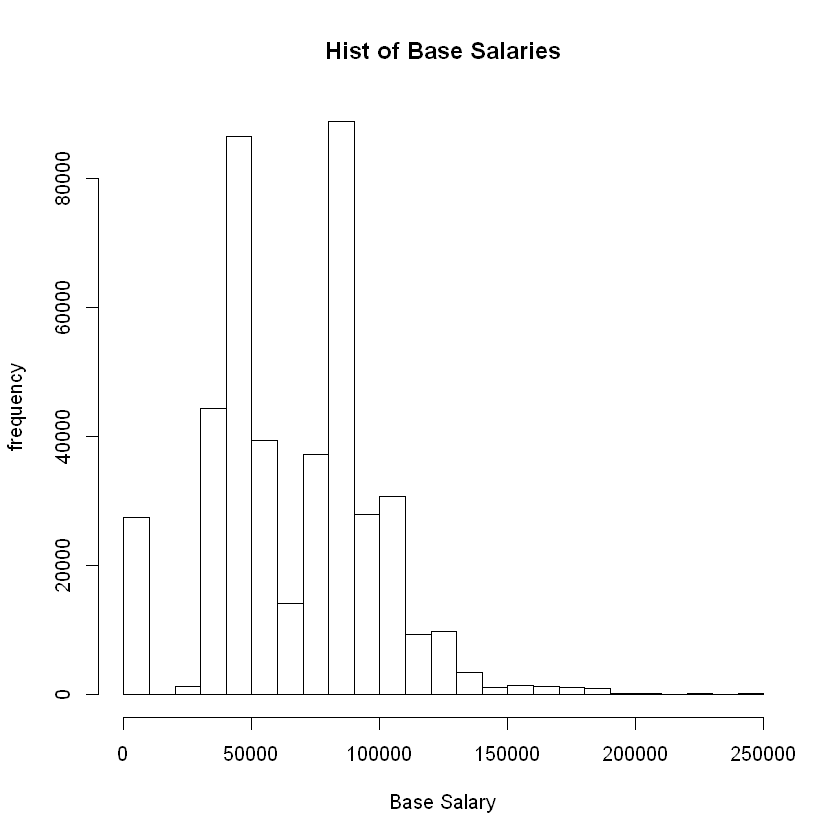

```r
hist(pol_dept$Base.Salary, main = "Hist of Base Salaries",
     xlab = "Base Salary", ylab = "frequency")
```

There is a clear bimodal distribution which could reflect the differences in base salary for leadership vs non-leadership positions. We decided to explore whether this distribution is consistent across boroughs.

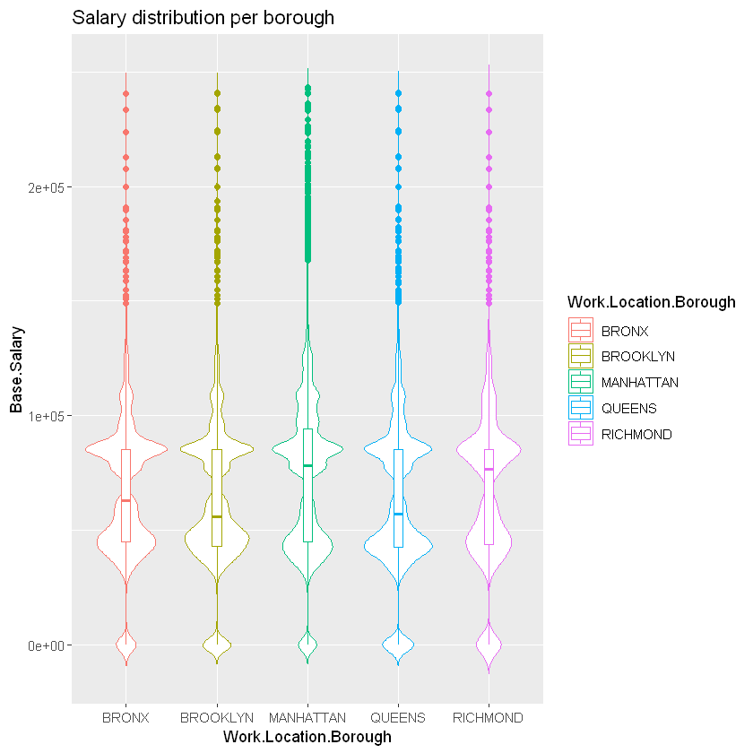

```r
vio_plot <-ggplot(pol_dept, aes(x=Work.Location.Borough,
                                   y=Base.Salary, color=Work.Location.Borough)) +
  geom_violin(trim=FALSE)
vio_plot + geom_boxplot(width=0.1) + ggtitle("Salary distribution per borough")
```

The bimodal distribution of base salary is consistent across boroughs. There are significant differences in mean base salary with the means in Manhattan and Richmond being the highest. Along with base salary, other measures of payment and working hours in the dataset include regular hours, regular gross paid, OT Hours, Total OT Paid, and Total Other Pay. Regular gross paid will be particularly important to explore as this is the amount of the base salary that is actually paid to an employee. One of the first questions we can ask is whether there is a positive correlation between regular hours and regular gross paid. A weaker correlation, for example, could suggest that employees are not being compensated for the amount of work they do.

```r
range(pol_dept$Regular.Hours)
range(pol_dept$Regular.Gross.Paid)
```

1. -1260

2. 2262.47

1. -29862.19

2. 487277.63

```r
neg_hours <- pol_dept %>% filter(Regular.Hours < 0)
dim(neg_hours)
unique(neg_hours$Leave.Status.as.of.June.30)
```

1. 402

2. 17

1. ON LEAVE

2. CEASED

3. ACTIVE

4. SEASONAL

**Levels**:**

1. 'ACTIVE'

2. 'CEASED'

3. 'ON LEAVE'

4. 'ON SEPARATION LEAVE'

5. 'SEASONAL'

```r
table(neg_hours$Leave.Status.as.of.June.30)
```

```
             ACTIVE              CEASED            ON LEAVE ON SEPARATION LEAVE
                  9                 287                 105                   0
           SEASONAL
                  1
```

The majority of people with negative hours are people are ceased or on leave. It's possible that these records could refer to employees who are retired and or on temporary leave (maternity, disability, etc) and are thus not logging hours but still receiving some form of pay.

```r
neg_gross_pay <- pol_dept %>% filter(Regular.Gross.Paid < 0)
dim(neg_gross_pay)
unique(neg_gross_pay$Leave.Status.as.of.June.30)
table(neg_gross_pay$Leave.Status.as.of.June.30)
```

1. 608

2. 17

1. CEASED

2. ACTIVE

3. ON LEAVE

**Levels**:**

1. 'ACTIVE'

2. 'CEASED'

3. 'ON LEAVE'

4. 'ON SEPARATION LEAVE'

5. 'SEASONAL'

```
             ACTIVE              CEASED            ON LEAVE ON SEPARATION LEAVE
                 11                 506                  91                   0
           SEASONAL
                  0
```

The majority of people who have a regular gross paid of less than zero are also "CEASED" which means that they possibly are receiving payment through other forms. Ultimately, we decided to keep the negative values as while they could simply indicate errors in data entry, it is also possible that the negative values are related to the leave status of the employee.

We can now take a look at the correlation between regular hours worked and regular gross paid per borough.

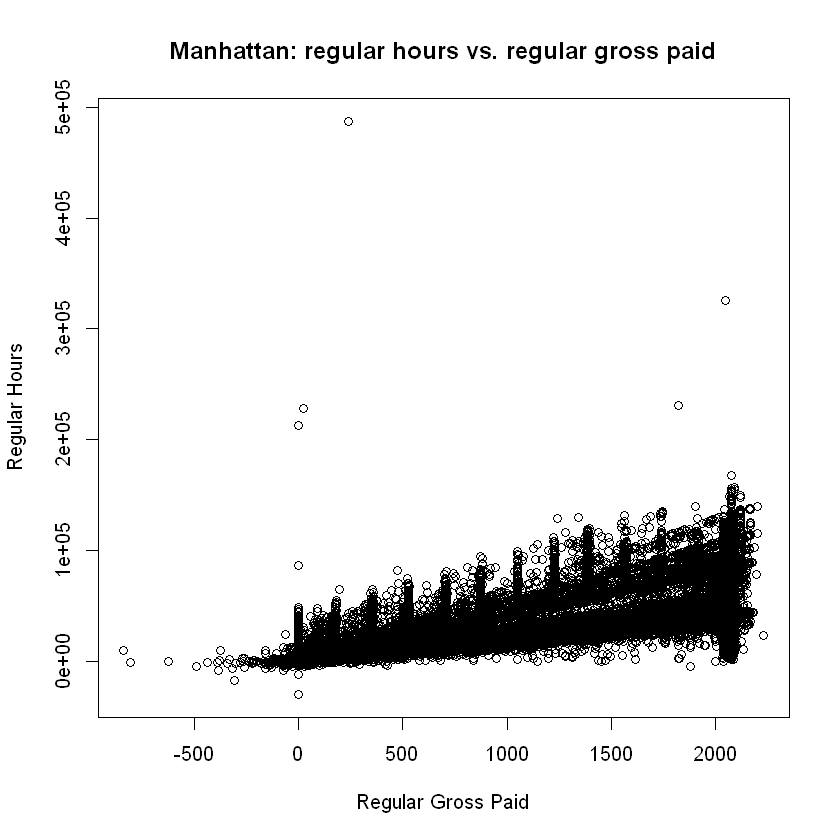

```r
# MANHATTAN
manhattan_df <- pol_dept %>% filter(Work.Location.Borough=="MANHATTAN" &
                                      Title.Description %in% top_ten_titles_pol)
plot(manhattan_df$Regular.Hours, jitter(manhattan_df$Regular.Gross.Paid),
     xlab = "Regular Gross Paid",
     ylab = "Regular Hours", main = "Manhattan: regular hours vs. regular gross paid")
```

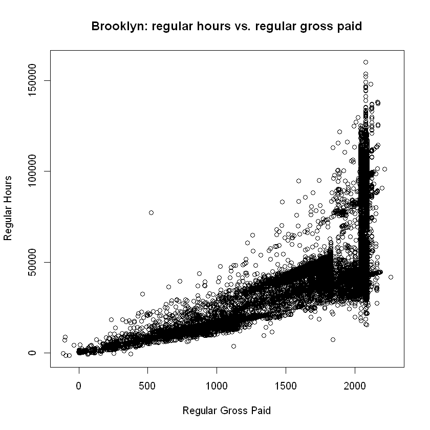

```r
# BROOKLYN
brooklyn_df <- pol_dept %>% filter(Work.Location.Borough=="BROOKLYN"
                                   & Title.Description %in% top_ten_titles_pol)
plot(brooklyn_df$Regular.Hours, jitter(brooklyn_df$Regular.Gross.Paid),
     xlab = "Regular Gross Paid",
     ylab = "Regular Hours", main = "Brooklyn: regular hours vs. regular gross paid")
```

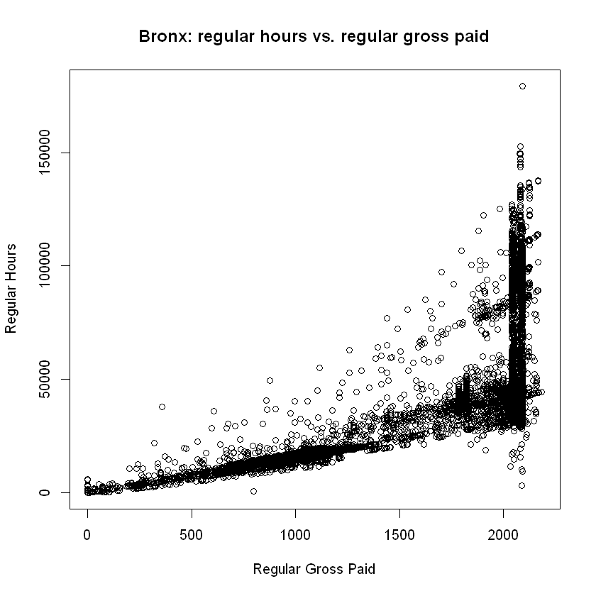

```r
# BRONX
bronx_df <- pol_dept %>% filter(Work.Location.Borough=="BRONX"
                                & Title.Description %in% top_ten_titles_pol)
plot(bronx_df$Regular.Hours, jitter(bronx_df$Regular.Gross.Paid),
     xlab = "Regular Gross Paid",
     ylab = "Regular Hours", main = "Bronx: regular hours vs. regular gross paid")
```

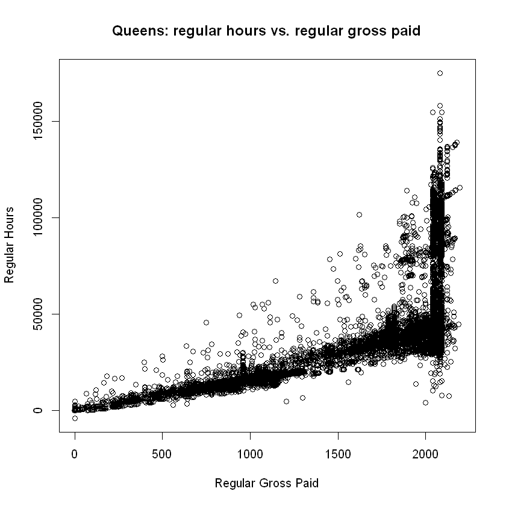

```r
# QUEENS
queens_df <- pol_dept %>% filter(Work.Location.Borough=="QUEENS"
                                 & Title.Description %in% top_ten_titles_pol)
plot(queens_df$Regular.Hours, jitter(queens_df$Regular.Gross.Paid),
     xlab = "Regular Gross Paid",
     ylab = "Regular Hours", main = "Queens: regular hours vs. regular gross paid")
```

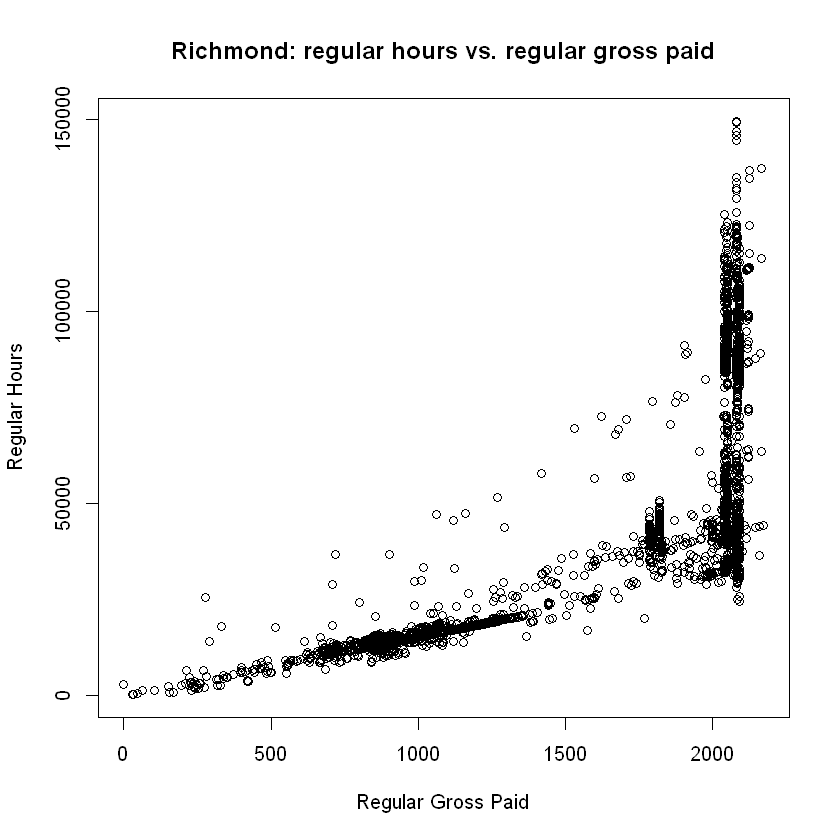

```r
#RICHMOND
richmond_df <- pol_dept %>% filter(Work.Location.Borough=="RICHMOND"
                                   & Title.Description %in% top_ten_titles_pol)
plot(richmond_df$Regular.Hours, jitter(richmond_df$Regular.Gross.Paid),
     xlab = "Regular Gross Paid",
     ylab = "Regular Hours", main = "Richmond: regular hours vs. regular gross paid")
```

Across the boroughs, there appears to be a moderate positive relationship between regular hours and regular gross paid.

#### Collinearity

The issue of collinearity can be explored in regard to the numerical data we have in the dataset. The above scatterplots have already begun to suggest that collinearity is present in the data, but we will create a correlation matrix to observe collinearity between the other features.

```r
num_cols <- c("Base.Salary", "Regular.Hours",
              "Regular.Gross.Paid", "OT.Hours",
              "Total.OT.Paid", "Total.Other.Pay")
just_num_cols <- pol_dept %>% select(num_cols)
```

```r
just_num_cols <- as.matrix(just_num_cols)
head(just_num_cols)
```

| Base.Salary | Regular.Hours | Regular.Gross.Paid | OT.Hours | Total.OT.Paid | Total.Other.Pay |
| --- | --- | --- | --- | --- | --- |
| 57813.0 | 0.00 | 0.00 | 0.00 | 0.00 | 650000.00 |
| 508.8 | 2080.00 | 140146.17 | 1125.25 | 117728.07 | 40696.41 |
| 141196.0 | 665.18 | 48008.86 | 2451.57 | 162000.47 | 78132.88 |
| 508.8 | 2080.00 | 140146.17 | 1007.00 | 103226.97 | 27980.42 |
| 85292.0 | 22.87 | 227914.67 | 0.00 | 0.00 | 30289.83 |
| 85292.0 | 1822.85 | 230597.55 | 55.27 | 3071.28 | 22856.71 |

```r
corr_matrix <- cor(just_num_cols)
head(corr_matrix)
```

|  | Base.Salary | Regular.Hours | Regular.Gross.Paid | OT.Hours | Total.OT.Paid | Total.Other.Pay |
| --- | --- | --- | --- | --- | --- | --- |
| Base.Salary | 1.0000000 | 0.2578305 | 0.7702636 | 0.2354725 | 0.4582337 | 0.6527142 |
| Regular.Hours | 0.2578305 | 1.0000000 | 0.6858270 | 0.4767524 | 0.4353665 | 0.4292326 |
| Regular.Gross.Paid | 0.7702636 | 0.6858270 | 1.0000000 | 0.3906496 | 0.5979354 | 0.7137946 |
| OT.Hours | 0.2354725 | 0.4767524 | 0.3906496 | 1.0000000 | 0.8497427 | 0.3442683 |
| Total.OT.Paid | 0.4582337 | 0.4353665 | 0.5979354 | 0.8497427 | 1.0000000 | 0.5251249 |
| Total.Other.Pay | 0.6527142 | 0.4292326 | 0.7137946 | 0.3442683 | 0.5251249 | 1.0000000 |

There does appear to be some collinearity between variables such as base salary and regular gross paid but this is expected as someone with a higher base salary will receive more gross pay. We also see high correlation between the number of overtime hours worked and the total overtime paid which is expected given that if someone is working more hours, they should be receiving more pay. It is interesting to observe that the correlation between regular hours and regular gross paid is not as high as the correlation between overtime hours and overtime pay. This suggests that the number of regular hours worked was not as strongly related to how much an employee is actually being paid. When building a model to predict whether someone works with the agency after two years, it will be necessary to consider how to incorporate features that have collinearity.

## Additional 'Police Department' Agency

Upon further investigation into the agencies, we discovered that there was another agency labeled as "Police Department". We decided to join this agency to the larger "POLICE DEPARTMENT" agency and perform EDA analysis to determine what data to include in the model. Our EDA process for the joined data is described below; we chose to remove the code as we ultimetely decided to only use the 'POLICE DEPARTMENT' data in our model.

The "Police Department" data only records data for the year 2014 while the "POLICE DEPARTMENT" data includes the years 2015-2021 and also includes borough information. The 2014 dataset does not include borough information. Based off of this exploration, we had two options for moving forward: we could have a year range of 2014-2021 and introduce data that does not have borough information or we could limit the year range to 2015-2021 and keep data that only has borough information. We used our EDA of the joined police departments and the "POLICE DEPARTMENT" agency alone to determine what data to include in the model. We also compared the proportion of employees that stop working after 2 years when using the joined police department subset and the "POLICE DEPARTMENT" agency alone.

The joined police department data is similar to the "POLICE DEPARTMENT" data alone in that the top ten positions account for 81% of the records for the agency and similar differences in base salary across title descriptions were observed. There are 861 employees in the smaller police department that are not in the larger police department subset.There are employees that are not included in the larger "POLICE DEPARTMENT" dataset. We can not know for certain the leave status of these employees after the year 2014. Therefore, this issue, along with the fact that records in the "Police Department" agency do not have information on boroughs makes this data less desirable for inclusion in the model.

We joined the datsets so that an extra year was represented and changed the missing borough values to "UNKNOWN". We first decided to look at the distribution of base salary. We examined the same viola and borough scatter plots as for 'POLICE DEPARTMENT' alone and determined that the plots were all similar. We examined the collinearity and observed the same features displaying collinearity as in the "POLICE DEPARTMENT" subset alone. When we included the "Police Department" Agency, the proportion of individuals who stopped working after 2 year was 4.19% and now without it the proportion of individuals is 4.62%.

The difference in proportions seems to suggest that there is not a significant change in proportion when we don't include the "Police Department" Agency. We also established earlier that the EDA of the "POLICE DEPARTMENT" records and the EDA of the joined police department records yielded similar results. As we intend to introduce external data that is specific to boroughs, we decided that it would be appropriate to proceed with using the records from the "POLICE DEPARTMENT" agency only for initial algorithm development.

## Total Years Column

In order to determine if someone leaves the agency after two years, we decided to first find the number of total years they have worked. We are particularly interested in the turnover rate per borough as the movement of one person from one borough to another could lead to management having to find a replacement for an employee and contribute to training costs. As we're interested in comparing turnover rates between boroughs, we decided to group records by both names and borough. This is because there are employees who who have worked in multiple boroughs.

In some instances, an individual has multiple start years for the same borough. An example is an employee that first started in Manhattan in 2016 and was ceased in 2017. She then started in Queens in 2018 and is listed as still active there despite the data also showing that she started in Manhattan again in 2019 and has since been ceased in Manhattan. In order to deal with data quality issues such as these, we decided to take the minimum start year per borough. While this assumption ignores that she seemingly joined the Manhattan borough again, this assumption was necessary to be consistent with the fact that she is still active in Queens. This example employee has different total years worked per borough which is the desired outcome given our aim of exploring how turnover rate can vary between borough.

```r
ceased_pol_dept <- pol_dept %>%
  filter(Leave.Status.as.of.June.30=="CEASED")
```

```r
# There are 30642 unique cases in which the person and the borough in which they work in have been marked as ceased
uniq_ceased_pol_dept <- ceased_pol_dept %>%
  distinct(Last.Name, First.Name,Mid.Init,
           Work.Location.Borough, .keep_all = TRUE)
nrow(uniq_ceased_pol_dept)
```

30642

```r
years_ceased <- ceased_pol_dept %>%
  group_by(Last.Name, First.Name, Mid.Init, Work.Location.Borough) %>%
  summarize(year_ceased = min(Fiscal.Year))
nrow(years_ceased)
```

30642

```r
dim(pol_dept)
pol_dept_w_year_ceased <- pol_dept %>%
  full_join(years_ceased, by =c("Last.Name", "First.Name", "Mid.Init",
                                "Work.Location.Borough"))
dim(pol_dept_w_year_ceased)
```

1. 426753

2. 17

1. 426753

2. 18

```r
class(pol_dept_w_year_ceased$Agency.Start.Date)
pol_dept_w_year_ceased$Start.Year <- substr(pol_dept_w_year_ceased$Agency.Start.Date, 1,4)
pol_dept_w_year_ceased$Start.Year <- as.integer(pol_dept_w_year_ceased$Start.Year)
dim(pol_dept_w_year_ceased)
```

'Date'

1. 426753

2. 19

```r
# we need the start year of the borough from which they were ceased
pol_dept_w__min_start_year <- pol_dept_w_year_ceased %>%
  group_by(Last.Name, First.Name, Mid.Init, Work.Location.Borough) %>%
  summarize(Min.Start.Year = min(Start.Year))
```

```r
before_total_years <- pol_dept_w_year_ceased %>%
  full_join(pol_dept_w__min_start_year, by = c("Last.Name", "First.Name",
                                               "Mid.Init", "Work.Location.Borough"))
```

```r
pol_dept_w_total_years <- before_total_years %>%
  mutate(total_years=ifelse(Leave.Status.as.of.June.30 =="CEASED",
                                   year_ceased-Min.Start.Year,
                             2021-Start.Year))
dim(pol_dept_w_total_years)
```

1. 426753

2. 21

```r
range(pol_dept_w_total_years$total_years)
```

1. 0

2. 59

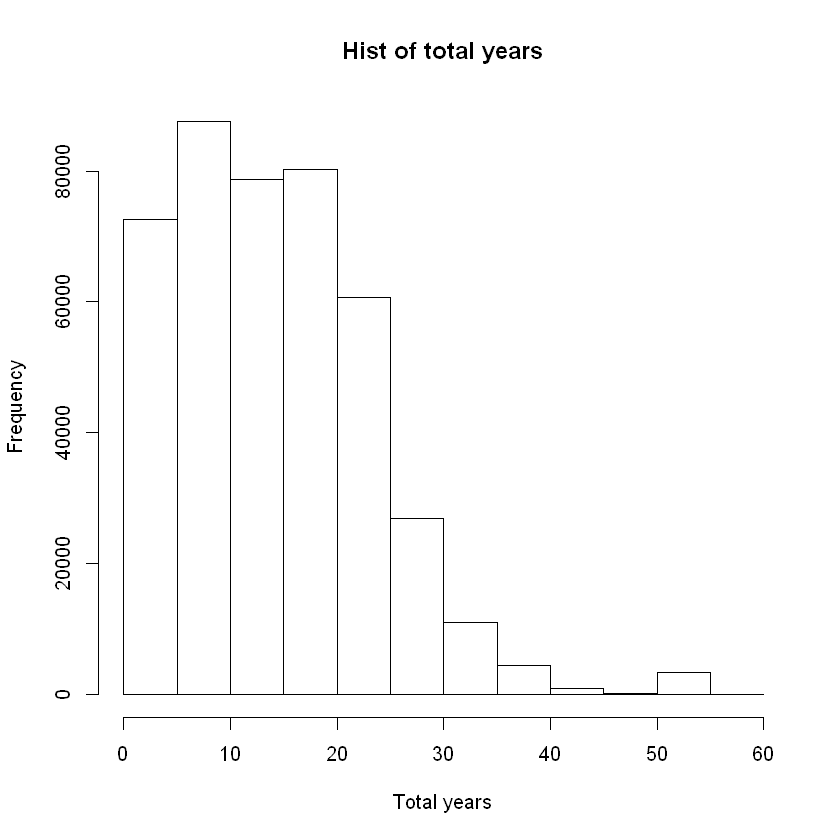

```r
hist(pol_dept_w_total_years$total_years,
     xlab = "Total years", main = "Hist of total years")
```

The range of total years is still between 0-59 years with the majority lying in between 0-25 years.

## Binary Column

We now need to create a binary column that classifies an employee by whether they have stopped working after 2 years. In other words, a value of 1 will indicate that they stopped working after 2 years.

```r
dim(pol_dept_w_total_years)
dim(pol_dept)
```

1. 426753

2. 21

1. 426753

2. 17

```r
final_df <- pol_dept_w_total_years %>%
  mutate(has_stopped = if_else(total_years <=2, 1, 0))
```

```r
(sum(final_df$has_stopped == 1)/nrow(final_df))*100
```

4.62609518855169

## Introducing New Features

### Crime counts per borough per year (external data)

We wanted to explore whether increasing crime rates had an effect on turnover rate among police officers. We were able to find a data set from the NYC open data that had records of crime incidents ranging from the 1920s to 2021. There are 449,506 incidents recorded with 36 variables describing each incident.

We wanted to create new features that would give the number of incidents of crime for each year and borough. We also chose to break the crime incidents into different categories as we thought that may be of additional significance to our posed question. For instance, it seems reasonable that theoretically increasing felony crimes would have an affect on police turnover while violations did not have an effect or as strong an effect. We used the recorded start date of the incident to categorize the year of the crime, the borough name to determine its location, and the law category variable to determine the type of crime. The law category variable broke the crimes into felonies, misdemeanors, and violations. We could have categorized the crimes in another manner, for instance violent and non-violent but this process seemed to require us to make our own assumptions and we wanted to avoid this.

The crime instances of each type were grouped and counted by the year and borough. The result was 3 new features that give the number of incidents of crime of the 3 types for each year and borough.

```r
# we want to get the crimes dataset
df_crime <-read.csv("NYPD_Complaint_Data_Current__Year_To_Date.csv")
```

```r
# lots of entries
df_crime %>% dim
df_crime %>% names %>% head
```

1. 449506

2. 36

1. 'CMPLNT_NUM'

2. 'ADDR_PCT_CD'

3. 'BORO_NM'

4. 'CMPLNT_FR_DT'

5. 'CMPLNT_FR_TM'

6. 'CMPLNT_TO_DT'

```r
# CMPLNT_FR_DT is the starting date on the incident
df_crime$CMPLNT_FR_DT %>% class
# we'll want to format the date
```

'factor'

```r
df_crime$BORO_NM %>% unique
df_crime$PATROL_BORO %>% unique
# this is too detailed to be useful with our other data set
```

2. BRONX

3. MANHATTAN

4. BROOKLYN

5. STATEN ISLAND

6. QUEENS

**Levels**:**

1. ''

2. 'BRONX'

3. 'BROOKLYN'

4. 'MANHATTAN'

5. 'QUEENS'

6. 'STATEN ISLAND'

2. PATROL BORO BRONX

3. PATROL BORO MAN SOUTH

4. PATROL BORO BKLYN SOUTH

5. PATROL BORO MAN NORTH

6. PATROL BORO STATEN ISLAND

7. PATROL BORO QUEENS SOUTH

8. PATROL BORO BKLYN NORTH

9. PATROL BORO QUEENS NORTH

**Levels**:**

1. ''

2. 'PATROL BORO BKLYN NORTH'

3. 'PATROL BORO BKLYN SOUTH'

4. 'PATROL BORO BRONX'

5. 'PATROL BORO MAN NORTH'

6. 'PATROL BORO MAN SOUTH'

7. 'PATROL BORO QUEENS NORTH'

8. 'PATROL BORO QUEENS SOUTH'

9. 'PATROL BORO STATEN ISLAND'

```r
# look at potential categorization for the crimes
df_crime$OFNS_DESC %>% unique %>% head
df_crime$PD_DESC %>% unique %>% head
```

1. MURDER & NON-NEGL. MANSLAUGHTER

2. DANGEROUS WEAPONS

3. FORGERY

4. ROBBERY

5. ARSON

6. DANGEROUS DRUGS

**Levels**:**

1. ''

2. 'ADMINISTRATIVE CODE'

3. 'AGRICULTURE & MRKTS LAW-UNCLASSIFIED'

4. 'ALCOHOLIC BEVERAGE CONTROL LAW'

5. 'ANTICIPATORY OFFENSES'

6. 'ARSON'

7. 'ASSAULT 3 & RELATED OFFENSES'

8. 'BURGLAR\'S TOOLS'

9. 'BURGLARY'

10. 'CHILD ABANDONMENT/NON SUPPORT'

11. 'CRIMINAL MISCHIEF & RELATED OF'

12. 'CRIMINAL TRESPASS'

13. 'DANGEROUS DRUGS'

14. 'DANGEROUS WEAPONS'

15. 'DISORDERLY CONDUCT'

16. 'DISRUPTION OF A RELIGIOUS SERV'

17. 'ENDAN WELFARE INCOMP'

18. 'ESCAPE 3'

19. 'FELONY ASSAULT'

20. 'FELONY SEX CRIMES'

21. 'FORGERY'

22. 'FRAUDS'

23. 'FRAUDULENT ACCOSTING'

24. 'GAMBLING'

25. 'GRAND LARCENY'

26. 'GRAND LARCENY OF MOTOR VEHICLE'

27. 'HARRASSMENT 2'

28. 'HOMICIDE-NEGLIGENT-VEHICLE'

29. 'HOMICIDE-NEGLIGENT,UNCLASSIFIE'

30. 'INTOXICATED & IMPAIRED DRIVING'

31. 'INTOXICATED/IMPAIRED DRIVING'

32. 'JOSTLING'

33. 'KIDNAPPING'

34. 'KIDNAPPING & RELATED OFFENSES'

35. 'LOITERING/GAMBLING (CARDS, DIC'

36. 'MISCELLANEOUS PENAL LAW'

37. 'MURDER & NON-NEGL. MANSLAUGHTER'

38. 'NEW YORK CITY HEALTH CODE'

39. 'NYS LAWS-UNCLASSIFIED FELONY'

40. 'NYS LAWS-UNCLASSIFIED VIOLATION'

41. 'OFF. AGNST PUB ORD SENSBLTY &'

42. 'OFFENSES AGAINST MARRIAGE UNCL'

43. 'OFFENSES AGAINST PUBLIC ADMINI'

44. 'OFFENSES AGAINST PUBLIC SAFETY'

45. 'OFFENSES AGAINST THE PERSON'

46. 'OFFENSES INVOLVING FRAUD'

47. 'OFFENSES RELATED TO CHILDREN'

48. 'OTHER OFFENSES RELATED TO THEF'

49. 'OTHER STATE LAWS'

50. 'OTHER STATE LAWS (NON PENAL LA'

51. 'OTHER STATE LAWS (NON PENAL LAW)'

52. 'PETIT LARCENY'

53. 'PETIT LARCENY OF MOTOR VEHICLE'

54. 'POSSESSION OF STOLEN PROPERTY'

55. 'PROSTITUTION & RELATED OFFENSES'

56. 'RAPE'

57. 'ROBBERY'

58. 'SEX CRIMES'

59. 'THEFT-FRAUD'

60. 'THEFT OF SERVICES'

61. 'UNAUTHORIZED USE OF A VEHICLE'

62. 'UNLAWFUL POSS. WEAP. ON SCHOOL'

63. 'VEHICLE AND TRAFFIC LAWS'

2. WEAPONS POSSESSION 1 & 2

3. FORGERY,M.V. REGISTRATION

4. ROBBERY,BICYCLE

5. ARSON 2,3,4

6. MARIJUANA, SALE 4 & 5

**Levels**:**

1. ''

2. 'ABANDON ANIMAL'

3. 'ACCOSTING,FRAUDULENT'

4. 'ADM.CODE,UNCLASSIFIED MISDEMEA'

5. 'ADM.CODE,UNCLASSIFIED VIOLATIO'

6. 'AGGRAVATED CRIMINAL CONTEMPT'

7. 'AGGRAVATED HARASSMENT 1'

8. 'AGGRAVATED HARASSMENT 2'

9. 'AGGRAVATED SEXUAL ASBUSE'

10. 'AGRICULTURE & MARKETS LAW,UNCL'

11. 'AIRPOLLUTION'

12. 'ALCOHOLIC BEVERAGE CONTROL LAW'

13. 'ALCOHOLIC BEVERAGES,PUBLIC CON'

14. 'ARSON 1'

15. 'ARSON 2,3,4'

16. 'ARSON, MOTOR VEHICLE 1 2 3 & 4'

17. 'ASSAULT 2,1,UNCLASSIFIED'

18. 'ASSAULT 3'

19. 'ASSAULT OTHER PUBLIC SERVICE EMPLOYEE'

20. 'ASSAULT POLICE/PEACE OFFICER'

21. 'ASSAULT SCHOOL SAFETY AGENT'

22. 'ASSAULT TRAFFIC AGENT'

23. 'ASSEMBLY,UNLAWFUL'

24. 'ATTEND/SPECTATOR ANIMAL FIGHTING'

25. 'BAIL JUMPING 1 & 2'

26. 'BAIL JUMPING 3'

27. 'BRIBERY, POLICE OFFICER'

28. 'BRIBERY,COMMERCIAL'

29. 'BRIBERY,PUBLIC ADMINISTRATION'

30. 'BUILDING MATERIAL'

31. 'BURGLARS TOOLS,UNCLASSIFIED'

32. 'BURGLARY, TRUCK UNKNOWN TIME'

33. 'BURGLARY,COMMERCIAL,DAY'

34. 'BURGLARY,COMMERCIAL,NIGHT'

35. 'BURGLARY,COMMERCIAL,UNKNOWN TI'

36. 'BURGLARY,RESIDENCE,DAY'

37. 'BURGLARY,RESIDENCE,NIGHT'

38. 'BURGLARY,RESIDENCE,UNKNOWN TIM'

39. 'BURGLARY,TRUCK DAY'

40. 'BURGLARY,TRUCK NIGHT'

41. 'BURGLARY,UNCLASSIFIED,DAY'

42. 'BURGLARY,UNCLASSIFIED,NIGHT'

43. 'BURGLARY,UNCLASSIFIED,UNKNOWN'

44. 'CAUSE SPI/KILL ANIMAL'

45. 'CHECK,BAD'

46. 'CHILD ABANDONMENT'

47. 'CHILD, ENDANGERING WELFARE'

48. 'CHILD,ALCOHOL SALE TO'

49. 'CHILD,OFFENSES AGAINST,UNCLASS'

50. 'COERCION 1'

51. 'COERCION 2'

52. 'COMPUTER TAMPER/TRESSPASS'

53. 'COMPUTER UNAUTH. USE/TAMPER'

54. 'CONFINING ANIMAL IN VEHICLE/SHELTER'

55. 'CONSPIRACY 2, 1'

56. 'CONSPIRACY 4, 3'

57. 'CONTEMPT,CRIMINAL'

58. 'CONTROLLED SUBSTANCE, INTENT T'

59. 'CONTROLLED SUBSTANCE, POSSESSI'

60. 'CONTROLLED SUBSTANCE, SALE 4'

61. 'CONTROLLED SUBSTANCE, SALE 5'

62. 'CONTROLLED SUBSTANCE,INTENT TO'

63. 'CONTROLLED SUBSTANCE,POSSESS.'

64. 'CONTROLLED SUBSTANCE,POSSESS.-'

65. 'CONTROLLED SUBSTANCE,SALE 1'

66. 'CONTROLLED SUBSTANCE,SALE 2'

67. 'CONTROLLED SUBSTANCE,SALE 3'

68. 'COURSE OF SEXUAL CONDUCT AGAIN'

69. 'CREDIT CARD,UNLAWFUL USE OF'

70. 'CRIMINAL CONTEMPT 1'

71. 'CRIMINAL DISPOSAL FIREARM 1 &'

72. 'CRIMINAL MIS 2 & 3'

73. 'CRIMINAL MISCHIEF 4TH, GRAFFIT'

74. 'CRIMINAL MISCHIEF,UNCLASSIFIED 4'

75. 'CUSTODIAL INTERFERENCE 1'

76. 'CUSTODIAL INTERFERENCE 2'

77. 'DIS. CON.,AGGRAVATED'

78. 'DISORDERLY CONDUCT'

79. 'DRUG PARAPHERNALIA, POSSESSE'

80. 'EAVESDROPPING'

81. 'END WELFARE VULNERABLE ELDERLY PERSON'

82. 'ESCAPE 2,1'

83. 'ESCAPE 3'

84. 'EXPOSURE OF A PERSON'

85. 'FACILITATION 3,2,1, CRIMINAL'

86. 'FACILITATION 4, CRIMINAL'

87. 'FALSE ALARM FIRE'

88. 'FALSE REPORT 1,FIRE'

89. 'FALSE REPORT BOMB'

90. 'FALSE REPORT UNCLASSIFIED'

91. 'FIREWORKS'

92. 'FIREWORKS, POSSESS/USE'

93. 'FIREWORKS, SALE'

94. 'FORGERY-ILLEGAL POSSESSION,VEH'

95. 'FORGERY,DRIVERS LICENSE'

96. 'FORGERY,ETC.-MISD.'

97. 'FORGERY,ETC.,UNCLASSIFIED-FELO'

98. 'FORGERY,M.V. REGISTRATION'

99. 'FORGERY,PRESCRIPTION'

100. 'FRAUD,UNCLASSIFIED-FELONY'

101. 'FRAUD,UNCLASSIFIED-MISDEMEANOR'

102. 'GAMBLING 1,PROMOTING,BOOKMAKIN'

103. 'GAMBLING 1,PROMOTING,POLICY'

104. 'GAMBLING 2,PROMOTING,UNCLASSIF'

105. 'GAMBLING, DEVICE, POSSESSION'

106. 'GENERAL BUSINESS LAW / UNCLASSIFIED'

107. 'GENERAL BUSINESS LAW,TICKET SP'

108. 'GRAFFITI (ADMINISTRATIVE CODE-'

109. 'HARASSMENT,SUBD 1,CIVILIAN'

110. 'HARASSMENT,SUBD 3,4,5'

111. 'HEALTH CODE,UNCLASSIFIED MISDE'

112. 'HEALTHCARE/RENT.REG.'

113. 'HOMICIDE, NEGLIGENT, VEHICLE,'

114. 'HOMICIDE,NEGLIGENT,UNCLASSIFIE'

115. 'IMITATION PISTOL/AIR RIFLE'

116. 'IMPAIRED DRIVING,DRUG'

117. 'IMPERSONATION 1, POLICE OFFICE'

118. 'IMPERSONATION 2, PUBLIC SERVAN'

119. 'IMPRISONMENT 1,UNLAWFUL'

120. 'IMPRISONMENT 2,UNLAWFUL'

121. 'INAPPROPIATE SHELTER DOG LEFT'

122. 'INCEST 3'

123. 'INCOMPETENT PERSON,KNOWINGLY ENDANGERING'

124. 'INCOMPETENT PERSON,RECKLESSY ENDANGERING'

125. 'INTOXICATED DRIVING,ALCOHOL'

126. 'JOSTLING'

127. 'KIDNAPPING 1'

128. 'KIDNAPPING 2'

129. 'LARCENY, GRAND OF AUTO - ATTEM'

130. 'LARCENY, GRAND OF MOPED'

131. 'LARCENY, PETIT OF MOPED'

132. 'LARCENY,GRAND BY ACQUIRING LOS'

133. 'LARCENY,GRAND BY ACQUIRING LOST CREDIT CARD'

134. 'LARCENY,GRAND BY BANK ACCT COMPROMISE-ATM TRANSACTION'

135. 'LARCENY,GRAND BY BANK ACCT COMPROMISE-REPRODUCED CHECK'

136. 'LARCENY,GRAND BY BANK ACCT COMPROMISE-TELLER'

137. 'LARCENY,GRAND BY BANK ACCT COMPROMISE-UNAUTHORIZED PURCHASE'

138. 'LARCENY,GRAND BY BANK ACCT COMPROMISE-UNCLASSIFIED'

139. 'LARCENY,GRAND BY CREDIT CARD ACCT COMPROMISE-EXISTING ACCT'

140. 'LARCENY,GRAND BY DISHONEST EMP'

141. 'LARCENY,GRAND BY EXTORTION'

142. 'LARCENY,GRAND BY FALSE PROMISE-IN PERSON CONTACT'

143. 'LARCENY,GRAND BY FALSE PROMISE-NOT IN PERSON CONTACT'

144. 'LARCENY,GRAND BY IDENTITY THEFT-UNCLASSIFIED'

145. 'LARCENY,GRAND BY OPEN BANK ACCT'

146. 'LARCENY,GRAND BY OPEN CREDIT CARD (NEW ACCT)'

147. 'LARCENY,GRAND BY OPEN/COMPROMISE CELL PHONE ACCT'

148. 'LARCENY,GRAND BY THEFT OF CREDIT CARD'

149. 'LARCENY,GRAND FROM BOAT, UNATTENDED'

150. 'LARCENY,GRAND FROM BUILDING (NON-RESIDENCE) UNATTENDED'

151. 'LARCENY,GRAND FROM EATERY, UNATTENDED'

152. 'LARCENY,GRAND FROM NIGHT CLUB, UNATTENDED'

153. 'LARCENY,GRAND FROM OPEN AREAS, UNATTENDED'

154. 'LARCENY,GRAND FROM PERSON, BAG OPEN/DIP'

155. 'LARCENY,GRAND FROM PERSON,LUSH WORKER(SLEEPING/UNCON VICTIM)'

156. 'LARCENY,GRAND FROM PERSON,PERSONAL ELECTRONIC DEVICE(SNATCH)'

157. 'LARCENY,GRAND FROM PERSON,PICK'

158. 'LARCENY,GRAND FROM PERSON,PURS'

159. 'LARCENY,GRAND FROM PERSON,UNCL'

160. 'LARCENY,GRAND FROM PIER, UNATTENDED'

161. 'LARCENY,GRAND FROM RESIDENCE, UNATTENDED'

162. 'LARCENY,GRAND FROM RESIDENCE/BUILDING,UNATTENDED, PACKAGE THEFT INSIDE'

163. 'LARCENY,GRAND FROM RESIDENCE/BUILDING,UNATTENDED, PACKAGE THEFT OUTSIDE'

164. 'LARCENY,GRAND FROM RETAIL STORE, UNATTENDED'

165. 'LARCENY,GRAND FROM STORE-SHOPL'

166. 'LARCENY,GRAND FROM TRUCK, UNATTENDED'

167. 'LARCENY,GRAND FROM VEHICLE/MOTORCYCLE'

168. 'LARCENY,GRAND OF AUTO'

169. 'LARCENY,GRAND OF BICYCLE'

170. 'LARCENY,GRAND OF BOAT'

171. 'LARCENY,GRAND OF MOTORCYCLE'

172. 'LARCENY,GRAND OF TRUCK'

173. 'LARCENY,GRAND OF VEHICULAR/MOTORCYCLE ACCESSORIES'

174. 'LARCENY,GRAND PERSON,NECK CHAI'

175. 'LARCENY,PETIT BY ACQUIRING LOS'

176. 'LARCENY,PETIT BY CHECK USE'

177. 'LARCENY,PETIT BY CREDIT CARD U'

178. 'LARCENY,PETIT BY DISHONEST EMP'

179. 'LARCENY,PETIT BY FALSE PROMISE'

180. 'LARCENY,PETIT FROM AUTO'

181. 'LARCENY,PETIT FROM BOAT'

182. 'LARCENY,PETIT FROM BUILDING,UN'

183. 'LARCENY,PETIT FROM BUILDING,UNATTENDED, PACKAGE THEFT INSIDE'

184. 'LARCENY,PETIT FROM BUILDING,UNATTENDED, PACKAGE THEFT OUTSIDE'

185. 'LARCENY,PETIT FROM COIN MACHIN'

186. 'LARCENY,PETIT FROM OPEN AREAS,'

187. 'LARCENY,PETIT FROM PARKING MET'

188. 'LARCENY,PETIT FROM PIER'

189. 'LARCENY,PETIT FROM STORE-SHOPL'

190. 'LARCENY,PETIT FROM TRUCK'

191. 'LARCENY,PETIT OF AUTO'

192. 'LARCENY,PETIT OF BICYCLE'

193. 'LARCENY,PETIT OF LICENSE PLATE'

194. 'LARCENY,PETIT OF MOTORCYCLE'

195. 'LARCENY,PETIT OF VEHICLE ACCES'

196. 'LEAVING SCENE-ACCIDENT-PERSONA'

197. 'LEWDNESS,PUBLIC'

198. 'LOITERING,GAMBLING,OTHER'

199. 'LURING A CHILD'

200. 'MAKING TERRORISTIC THREAT'

201. 'MARIJUANA, POSSESSION'

202. 'MARIJUANA, POSSESSION 1, 2 & 3'

203. 'MARIJUANA, POSSESSION 4 & 5'

204. 'MARIJUANA, SALE 1, 2 & 3'

205. 'MARIJUANA, SALE 4 & 5'

206. 'MARRIAGE,OFFENSES AGAINST,UNCL'

207. 'MATERIAL OFFENSIV'

208. 'MENACING 1ST DEGREE (VICT NOT'

209. 'MENACING 1ST DEGREE (VICT PEAC'

210. 'MENACING,PEACE OFFICER'

211. 'MENACING,UNCLASSIFIED'

212. 'MISCHIEF 1,CRIMINAL,EXPLOSIVE'

213. 'MISCHIEF, CRIMINAL 3 & 2, OF M'

214. 'MISCHIEF, CRIMINAL 3&2, BY FIR'

215. 'MISCHIEF, CRIMINAL 4, BY FIRE'

216. 'MISCHIEF, CRIMINAL 4, OF MOTOR'

217. 'MISCHIEF,CRIMINAL, UNCL 2ND'

218. 'MONEY LAUNDERING 1 & 2'

219. 'N.Y.C. TRANSIT AUTH. R&R'

220. 'NEGLECT/POISON ANIMAL'

221. 'NUISANCE,CRIMINAL,UNCLASSIFIED'

222. 'NY STATE LAWS,UNCLASSIFIED FEL'

223. 'NY STATE LAWS,UNCLASSIFIED MIS'

224. 'NY STATE LAWS,UNCLASSIFIED VIO'

225. 'OBSCENE MATERIAL - UNDER 17 YE'

226. 'OBSCENITY 1'

227. 'OBSCENITY, MATERIAL 3'

228. 'OBSCENITY, PERFORMANCE 3'

229. 'OBSTR BREATH/CIRCUL'

230. 'PARKR&R,UNCLASSIFIED VIOLATION'

231. 'PEDDLING,UNLAWFUL'

232. 'PERJURY 2,1,ETC'

233. 'PETIT LARCENY-CHECK FROM MAILB'

234. 'PETIT LARCENY OF ANIMAL'

235. 'POSS METH MANUFACT MATERIAL'

236. 'POSSES OR CARRY A KNIFE'

237. 'POSSESSION HYPODERMIC INSTRUME'

238. 'POSTING ADVERTISEMENTS'

239. 'PRIVACY,OFFENSES AGAINST,UNCLA'

240. 'PROMOTING A SEXUAL PERFORMANCE'

241. 'PROMOTING SUICIDE ATTEMPT'

242. 'PROSTITUTION'

243. 'PROSTITUTION 3, PROMOTING UNDE'

244. 'PROSTITUTION 3,PROMOTING BUSIN'

245. 'PROSTITUTION, PATRONIZING 4, 3'

246. 'PUBLIC ADMINISTATION,UNCLASS M'

247. 'PUBLIC ADMINISTRATION,UNCLASSI'

248. 'PUBLIC HEALTH LAW,GLUE,UNLAWFU'

249. 'PUBLIC HEALTH LAW,UNCLASSIFIED'

250. 'PUBLIC SAFETY,UNCLASSIFIED MIS'

251. 'RAPE 1'

252. 'RAPE 1,ATTEMPT'

253. 'RAPE 2'

254. 'RAPE 3'

255. 'RECKLESS DRIVING'

256. 'RECKLESS ENDANGERMENT 1'

257. 'RECKLESS ENDANGERMENT 2'

258. 'RECKLESS ENDANGERMENT OF PROPE'

259. 'RECORDS,FALSIFY-TAMPER'

260. 'RESISTING ARREST'

261. 'RIOT 1'

262. 'RIOT 2/INCITING'

263. 'ROBBERY, CHAIN STORE'

264. 'ROBBERY, PAYROLL'

265. 'ROBBERY,ATM LOCATION'

266. 'ROBBERY,BANK'

267. 'ROBBERY,BAR/RESTAURANT'

268. 'ROBBERY,BEGIN AS SHOPLIFTING'

269. 'ROBBERY,BICYCLE'

270. 'ROBBERY,BODEGA/CONVENIENCE STORE'

271. 'ROBBERY,CAR JACKING'

272. 'ROBBERY,CHECK CASHING BUSINESS'

273. 'ROBBERY,CLOTHING'

274. 'ROBBERY,COMMERCIAL UNCLASSIFIED'

275. 'ROBBERY,DELIVERY PERSON'

276. 'ROBBERY,DOCTOR/DENTIST OFFICE'

277. 'ROBBERY,DWELLING'

278. 'ROBBERY,GAS STATION'

279. 'ROBBERY,HIJACKING'

280. 'ROBBERY,HOME INVASION'

281. 'ROBBERY,LICENSED FOR HIRE VEHICLE'

282. 'ROBBERY,LICENSED MEDALLION CAB'

283. 'ROBBERY,LIQUOR STORE'

284. 'ROBBERY,NECKCHAIN/JEWELRY'

285. 'ROBBERY,OF TRUCK DRIVER'

286. 'ROBBERY,ON BUS/ OR BUS DRIVER'

287. 'ROBBERY,OPEN AREA UNCLASSIFIED'

288. 'ROBBERY,PERSONAL ELECTRONIC DEVICE'

289. 'ROBBERY,PHARMACY'

290. 'ROBBERY,POCKETBOOK/CARRIED BAG'

291. 'ROBBERY,PUBLIC PLACE INSIDE'

292. 'ROBBERY,RESIDENTIAL COMMON AREA'

293. 'ROBBERY,UNLICENSED FOR HIRE VEHICLE'

294. 'SALE SCHOOL GROUNDS'

295. 'SALE SCHOOL GROUNDS 4'

296. 'SEX CRIMES'

297. 'SEX TRAFFICKING'

298. 'SEXUAL ABUSE'

299. 'SEXUAL ABUSE 3,2'

300. 'SEXUAL MISCONDUCT,DEVIATE'

301. 'SEXUAL MISCONDUCT,INTERCOURSE'

302. 'SODOMY 1'

303. 'SODOMY 2'

304. 'SODOMY 3'

305. 'SOLICITATION 3,2,1, CRIMINAL'

306. 'SOLICITATION 4, CRIMINAL'

307. 'STALKING COMMIT SEX OFFENSE'

308. 'STOLEN PROP-MOTOR VEHICLE 3RD,'

309. 'STOLEN PROPERTY-MOTOR VEH 2ND,'

310. 'STOLEN PROPERTY 2,1,POSSESSION'

311. 'STOLEN PROPERTY 3,POSSESSION'

312. 'STRANGULATION 1ST'

313. 'SUPP. ACT TERR 2ND'

314. 'TAMPERING 1,CRIMINAL'

315. 'TAMPERING 3,2, CRIMINAL'

316. 'TAMPERING WITH A WITNESS'

317. 'TAX LAW'

318. 'TERRORISM PROVIDE SUPPORT'

319. 'THEFT OF SERVICES, UNCLASSIFIE'

320. 'THEFT,RELATED OFFENSES,UNCLASS'

321. 'TORTURE/INJURE ANIMAL CRUELTY'

322. 'TRAFFIC,UNCLASSIFIED MISDEMEAN'

323. 'TRESPASS 1,CRIMINAL'

324. 'TRESPASS 2, CRIMINAL'

325. 'TRESPASS 3, CRIMINAL'

326. 'TRESPASS 4,CRIMINAL SUB 2'

327. 'UNAUTH. SALE OF TRANS. SERVICE'

328. 'UNAUTHORIZED USE VEHICLE 2'

329. 'UNAUTHORIZED USE VEHICLE 3'

330. 'UNLAWFUL DISCLOSURE OF AN INTIMATE IMAGE'

331. 'UNLAWFUL POSS. WEAPON UPON SCH'

332. 'USE OF A CHILD IN A SEXUAL PER'

333. 'VEHICULAR ASSAULT (INTOX DRIVE'

334. 'VIOLATION OF ORDER OF PROTECTI'

335. 'WEAPONS POSSESSION 1 & 2'

336. 'WEAPONS POSSESSION 3'

337. 'WEAPONS, POSSESSION, ETC'

338. 'WOUNDS,REPORTING OF'

```r
# separate by type of crime
df_crime$LAW_CAT_CD %>% unique
```

1. FELONY

2. MISDEMEANOR

3. VIOLATION

**Levels**:**

1. 'FELONY'

2. 'MISDEMEANOR'

3. 'VIOLATION'

```r
df_cs <- df_crime[ ,c("LAW_CAT_CD", "BORO_NM", "CMPLNT_FR_DT")]
head(df_cs)
```

| LAW_CAT_CD | BORO_NM | CMPLNT_FR_DT |
| --- | --- | --- |
| FELONY |  | 12/17/2021 |
| FELONY |  | 12/17/2021 |
| FELONY |  | 12/13/2021 |
| FELONY | BRONX | 12/07/2021 |
| FELONY |  | 12/06/2021 |
| FELONY |  | 12/05/2021 |

```r
# remove the entries without borough information
df_cs <- df_cs[!(df_cs$BORO_NM==""),]
```

```r
df_cs$CMPLNT_FR_DT <- df_cs$CMPLNT_FR_DT %>% mdy
df_cs$Year <- df_cs$CMPLNT_FR_DT %>% year

df_cs$CMPLNT_FR_DT %>% year %>% unique %>% sort(., decreasing = T) %>% head
```

1. 2021

2. 2020

3. 2019

4. 2018

5. 2017

6. 2016

```r
# keep dates that are consistent with agency dataset
df_cs <- df_cs %>% filter(Year %in% 2015:2021)
df_crime_counts <- df_cs %>% filter(LAW_CAT_CD=="FELONY") %>%
  count(BORO_NM , Year)
```

```r
names(df_crime_counts)[3] <- "Felonies"
```

```r
df_crime_counts %>% head
df_crime_counts$Misdemeanors <- (df_cs %>% filter(LAW_CAT_CD=="MISDEMEANOR") %>%
                                   count(BORO_NM , Year))[[3]]
```

| BORO_NM | Year | Felonies |
| --- | --- | --- |
| BRONX | 2015 | 13 |
| BRONX | 2016 | 27 |
| BRONX | 2017 | 24 |
| BRONX | 2018 | 44 |
| BRONX | 2019 | 94 |
| BRONX | 2020 | 694 |

```r
df_crime_counts %>% head
x <- (df_cs %>% filter(LAW_CAT_CD=="VIOLATION") %>%
        count(BORO_NM , Year))
names(x)[3] <- "Violations"
```

| BORO_NM | Year | Felonies | Misdemeanors |
| --- | --- | --- | --- |
| BRONX | 2015 | 13 | 7 |
| BRONX | 2016 | 27 | 11 |
| BRONX | 2017 | 24 | 17 |
| BRONX | 2018 | 44 | 27 |
| BRONX | 2019 | 94 | 71 |
| BRONX | 2020 | 694 | 655 |

```r
df_crime_data <- merge(df_crime_counts, x, all=T)

df_crime_data[is.na(df_crime_data)] <- 0

dim(df_crime_data)
head(df_crime_data)
unique(df_crime_data$BORO_NM)
```

1. 35

2. 5

| BORO_NM | Year | Felonies | Misdemeanors | Violations |
| --- | --- | --- | --- | --- |
| BRONX | 2015 | 13 | 7 | 1 |
| BRONX | 2016 | 27 | 11 | 4 |
| BRONX | 2017 | 24 | 17 | 3 |
| BRONX | 2018 | 44 | 27 | 4 |
| BRONX | 2019 | 94 | 71 | 7 |
| BRONX | 2020 | 694 | 655 | 95 |

1. BRONX

2. BROOKLYN

3. MANHATTAN

4. QUEENS

5. STATEN ISLAND

**Levels**:**

1. ''

2. 'BRONX'

3. 'BROOKLYN'

4. 'MANHATTAN'

5. 'QUEENS'

6. 'STATEN ISLAND'

```r
df_crime_data$BORO_NM <- sub("STATEN ISLAND",
                             "RICHMOND", df_crime_data$BORO_NM)
unique(df_crime_data$BORO_NM)
```

1. 'BRONX'

2. 'BROOKLYN'

3. 'MANHATTAN'

4. 'QUEENS'

5. 'RICHMOND'

```r
names(df_crime_data)[names(df_crime_data) == "BORO_NM"] <- "Work.Location.Borough"
names(df_crime_data)[names(df_crime_data) == "Year"] <- "Fiscal.Year"
```

### Proportion of Leadership Positions

Our aim was to create a feature that communicated the proportion of leadership positions to total positions within the Police Department. We predicted that turnover rates may be affected by the percentage of leadership positions to total positions as having more leadership could give guidance to new recruits and also an area with a higher leadership ratio may be indicative of more opportunity for promotion.

The feature was created using a true/false column which indicated whether a certain column contained key words identified as being associated with leadership positions. These words were chosen based on the job titles that had the most salaries associated with them as well as a scan on the unique job titles vector.

The data was grouped by borough and year and the mean of this column was calculated. This value is the fraction of leadership positions to total positions for each year and borough combination. Manhattan had a higher percentage than the other boroughs.

```r
pol_dept %>% names
```

1. 'Fiscal.Year'

2. 'Payroll.Number'

3. 'Agency.Name'

4. 'Last.Name'

5. 'First.Name'

6. 'Mid.Init'

7. 'Agency.Start.Date'

8. 'Work.Location.Borough'

9. 'Title.Description'

10. 'Leave.Status.as.of.June.30'

11. 'Base.Salary'

12. 'Pay.Basis'

13. 'Regular.Hours'

14. 'Regular.Gross.Paid'

15. 'OT.Hours'

16. 'Total.OT.Paid'

17. 'Total.Other.Pay'

```r
# proportion of active employees with leadership titles to total employees.
toMatch <- c("SUPERVISOR", "LIEUTENANT",
             "COMMANDER", "CAPTAIN", "COMMISSIONER", "CAPT", "CHIEF",
             "DIRECTOR", "SERGEANT", "MANAGER")
matches <- grepl(paste(toMatch,collapse="|"), pol_dept$Title.Description)
```

```r
matches %>% length
pol_dept %>% dim

# add whether its a match or not to the data set
pol_dept$rank <- matches

# the total ratio for management buzzwords
sum(pol_dept$rank)/length(pol_dept$rank)

# separated by borough and year

# percent of positions in each borough for each year that are managers
df_managers <- aggregate(pol_dept$rank,
                         by=list(Fiscal.Year=pol_dept$Fiscal.Year,Borough = pol_dept$Work.Location.Borough),mean)
```

426753

1. 426753

2. 17

0.138522752036893

```r
dim(df_managers)
head(df_managers)
unique(df_managers$Borough)
```

1. 35

2. 3

| Fiscal.Year | Borough | x |
| --- | --- | --- |
| 2015 | BRONX | 0.1230530 |
| 2016 | BRONX | 0.1192876 |
| 2017 | BRONX | 0.1171990 |
| 2018 | BRONX | 0.1153335 |
| 2019 | BRONX | 0.1135348 |
| 2020 | BRONX | 0.1166891 |

1. BRONX

2. BROOKLYN

3. MANHATTAN

4. QUEENS

5. RICHMOND

**Levels**:**

1. ''

2. 'ALBANY'

3. 'Bronx'

4. 'BRONX'

5. 'BROOKLYN'

6. 'DELAWARE'

7. 'DUTCHESS'

8. 'GREENE'

9. 'Manhattan'

10. 'MANHATTAN'

11. 'NASSAU'

12. 'ORANGE'

13. 'OTHER'

14. 'PUTNAM'

15. 'Queens'

16. 'QUEENS'

17. 'Richmond'

18. 'RICHMOND'

19. 'SCHOHARIE'

20. 'SULLIVAN'

21. 'ULSTER'

22. 'WASHINGTON DC'

23. 'WESTCHESTER'

```r
names(df_managers)[names(df_managers) == "Borough"] <- "Work.Location.Borough"
names(df_managers)[names(df_managers) == "x"] <- "Leadership.Percentage"
```

## Joining External Data to "POLICE DEPARTMENT"

We currently have 3 data frames that we want to join in order to have our original predictor variables as well as new features and response variable in the same frame. We will join our data by the fiscal years and borough columns as these are the same across the 3 data frames and will include all data. The result of this join is that our original data frame now has additional features for each fiscal year and borough. These features correspond to the leadership percentages and the crime counts of each type.

```r
unique(final_df$Work.Location.Borough)
unique(df_managers$Work.Location.Borough)
unique(df_crime_data$Work.Location.Borough)
dim(final_df)
```

1. MANHATTAN

2. BROOKLYN

3. BRONX

4. QUEENS

5. RICHMOND

**Levels**:**

1. ''

2. 'ALBANY'

3. 'Bronx'

4. 'BRONX'

5. 'BROOKLYN'

6. 'DELAWARE'

7. 'DUTCHESS'

8. 'GREENE'

9. 'Manhattan'

10. 'MANHATTAN'

11. 'NASSAU'

12. 'ORANGE'

13. 'OTHER'

14. 'PUTNAM'

15. 'Queens'

16. 'QUEENS'

17. 'Richmond'

18. 'RICHMOND'

19. 'SCHOHARIE'

20. 'SULLIVAN'

21. 'ULSTER'

22. 'WASHINGTON DC'

23. 'WESTCHESTER'

1. BRONX

2. BROOKLYN

3. MANHATTAN

4. QUEENS

5. RICHMOND

**Levels**:**

1. ''

2. 'ALBANY'

3. 'Bronx'

4. 'BRONX'

5. 'BROOKLYN'

6. 'DELAWARE'

7. 'DUTCHESS'

8. 'GREENE'

9. 'Manhattan'

10. 'MANHATTAN'

11. 'NASSAU'

12. 'ORANGE'

13. 'OTHER'

14. 'PUTNAM'

15. 'Queens'

16. 'QUEENS'

17. 'Richmond'

18. 'RICHMOND'

19. 'SCHOHARIE'

20. 'SULLIVAN'

21. 'ULSTER'

22. 'WASHINGTON DC'

23. 'WESTCHESTER'

1. 'BRONX'

2. 'BROOKLYN'

3. 'MANHATTAN'

4. 'QUEENS'

5. 'RICHMOND'

1. 426753

2. 22

```r
pol_ext_df <- merge(final_df, df_managers,
                    by=c("Work.Location.Borough", "Fiscal.Year"), all = T)
dim(pol_ext_df)
```

1. 426753

2. 23

```r
pol_ext_final_df <- merge(pol_ext_df, df_crime_data,
                          by=c("Work.Location.Borough", "Fiscal.Year"), all = T)
dim(pol_ext_final_df)
```

1. 426753

2. 26

## Building the algorithm

In order to start the process of fitting an algorithm to our data to make predictions and identify patterns, we needed to decide what predictor variables to include. We also need to split our data into training and test sets.

```r
pol_ext_final_df_sub <- pol_ext_final_df %>% select(-c(Payroll.Number, Agency.Name, Last.Name,
                                                       First.Name,Mid.Init, year_ceased,
                                                       Title.Description, total_years, Min.Start.Year))
names(pol_ext_final_df_sub)
```

1. 'Work.Location.Borough'

2. 'Fiscal.Year'

3. 'Agency.Start.Date'

4. 'Leave.Status.as.of.June.30'

5. 'Base.Salary'

6. 'Pay.Basis'

7. 'Regular.Hours'

8. 'Regular.Gross.Paid'

9. 'OT.Hours'

10. 'Total.OT.Paid'

11. 'Total.Other.Pay'

12. 'Start.Year'

13. 'has_stopped'

14. 'Leadership.Percentage'

15. 'Felonies'

16. 'Misdemeanors'

17. 'Violations'

We deleted payroll number from consideration for our model as it was uniform across all rows. We also deleted job title as it had too many levels to be practical for modeling. We removed the names for the same reason job titles were removed. We removed year ceased also due to its large number of NA values corresponding to those still active. We removed min.start.year as it was a column created to deal with data quality issues. Lastly, total years was removed as it directly predicts whether someone has worked less than or equal to 2 years and could prevent our model from accurately detecting other patterns.

```r
set.seed(3106)
subset <- sample(nrow(pol_ext_final_df_sub), nrow(pol_ext_final_df_sub) * 0.80)
train_set  <- pol_ext_final_df_sub[subset, ]
test_set <- pol_ext_final_df_sub[-subset, ]
nrow(train_set)
nrow(test_set)
```

341402

85351

```r
# check proportion of has_stopped in test and train

# this value is off so the project might not really work anymore with this new method
sum(train_set$has_stopped == 1)/nrow(train_set)
sum(test_set$has_stopped == 1)/nrow(test_set)
```

0.0461889502697699

0.0465489566613162

We randomly split our data in train and test sets with 20% in the test and 80% in the train. We confirmed that the train and test sets have similar proportions of people who have stopped working after 2 years.

## Expectations

Prior to running our model, it is necessary to state our expectation based off of EDA and the current features we are planning to include.

```r
borough_count <- pol_ext_final_df_sub %>%
  group_by(Work.Location.Borough) %>%
  summarize(row_count = n())
borough_prop <- borough_count %>%
  mutate(proportion = row_count/nrow(pol_ext_final_df_sub))
head(borough_prop)
```

| Work.Location.Borough | row_count | proportion |
| --- | --- | --- |
| BRONX | 51486 | 0.12064590 |
| BROOKLYN | 97317 | 0.22804058 |
| MANHATTAN | 185919 | 0.43565950 |
| QUEENS | 78759 | 0.18455406 |
| RICHMOND | 13272 | 0.03109996 |

The borough that is most represented in the dataset is Manhattan.

```r
borough_years <- pol_ext_final_df %>%
  group_by(Work.Location.Borough) %>%
  summarize(Years = mean(total_years))
head(borough_years)
```

| Work.Location.Borough | Years |
| --- | --- |
| BRONX | 13.28652 |
| BROOKLYN | 13.23700 |
| MANHATTAN | 16.40706 |
| QUEENS | 13.53325 |
| RICHMOND | 14.20072 |

It appears that Manhattan has the greatest average number of total years worked by their employees. From this, we can expect that employees working in Manhattan may be less likely to leave after 2 years.

We also predict that generally higher leadership percentages will result in less turnover. More leadership adjusts new people to positions better and also indicates more opportunity for promotion within the organization. We also expect that an increase in regular gross paid will decrease the odds of turnover after 2 years.

We also predict that increasing crime will increase the odds of turnover. Recent articles have indicated that increasing crime is leading to early retirement and resignations. This may not necessarily correspond to turnover rates as we have defined them in this project. For instance, officers who have worked more than 2 years but are still resigning and retiring earlier than normal will not be considered as turnover. However, this trend may also affect new police officers and influence whether they stay more than 2 initial years.

## Natural Base Rate of Turnover Across Boroughs

In order to better evaluate our model, we want to compare its errors to the natural base errors based on a random binomial distribution. We modeled our natural predictions as a binomial distribution with a probability corresponding to the turnover rate we found from our original data. We compare these random predictions to our test set and calculate the classification, precision, and recall errors.

```r
set.seed(3106)
n <- nrow(test_set)
turnover_random <- sample(c("1", "0"),n,replace=TRUE, prob=c(0.0462,0.9538))
length(turnover_random)
length(test_set$has_stopped)
```

85351

85351

### classification error

```r
rand_class_error <- turnover_random != test_set$has_stopped
rand_class_error <- mean(rand_class_error)
print(rand_class_error)
```

```
[1] 0.08920809
```

### precision and recall

```r
rand_conf <- table(turnover_random, test_set$has_stopped)
print(rand_conf)
```

```
turnover_random     0     1
              0 77556  3792
              1  3822   181
```

```r
rand_precision <- rand_conf[2,2]/(rand_conf[2,2]+rand_conf[2,1])
print(rand_precision)
rand_recall <-rand_conf[2,2]/(rand_conf[2,2]+rand_conf[1,2])
print(rand_recall)
```

```
[1] 0.04521609
[1] 0.04555751
```

While the low classification error suggests that the random classification method works well, the precision and recall are poor.

## Logistic regression (to predict churn)

We decided to use logistic regression to predict churn as the problem we are trying to solve is an issue of classification. We are classifying records of a city employee's salary per fiscal year, given a specific borough, as either belonging to one of two classes. Those classes are either ceased after two years or not ceased after two years with 1 indicating that the employee was ceased after 2 years. Given that we have a lot more observations than features, we were able to proceed with using logistic regression. The limitation of logistic regression is that we established earlier that there is collinearity in the dataset. While collinearity will not affect predictions, it will be important to consider when we explore patterns.

```r
class(train_set$has_stopped)
train_set$has_stopped <- as.factor(train_set$has_stopped)
class(train_set$has_stopped)
log_reg <- glm(has_stopped ~ ., train_set,
              family=binomial(link="logit"))
```

'numeric'

'factor'

```r
test_set$has_stopped <- as.factor(test_set$has_stopped)
log_reg_preds <- predict(log_reg, test_set, type = "response")
rounded_log_preds <- if_else(log_reg_preds < 0.5, 0, 1)
```

### classification error

```r
log_class_error <- rounded_log_preds != test_set$has_stopped
log_class_error <- mean(log_class_error)
print(log_class_error)
```

```
[1] 0.006982929
```

### precision and recall

```r
log_conf <- table(rounded_log_preds, test_set$has_stopped)
print(log_conf)
```

```
rounded_log_preds     0     1
                0 81128   346
                1   250  3627
```

```r
log_precision <- log_conf[2,2]/(log_conf[2,2]+log_conf[2,1])
print(log_precision)
log_recall <-log_conf[2,2]/(log_conf[2,2]+log_conf[1,2])
print(log_recall)
```

```
[1] 0.9355172
[1] 0.9129122
```

To evaluate the performance of the logistic regression model, we can compare the evaluation metrics of classification error, precision, and recall to that of the model that predicted randomly (the natural base rate of turnover). The logistic regression model led to both lower classification error and higher precision and recall.

## Logistic regression (to identify patterns)

When considering the features that displayed high collinearity (>0.5) during the EDA, they included base salary and regular gross paid, base salary and total other pay, regular hours and regular gross paid, total OT paid and regular gross paid, total other pay and regular gross paid,OT hours and total OT paid,and total other pay and total OT paid.

We can first consider the output of the initial logistic regression model we ran.

```r
s <- summary(log_reg)
s$coefficients[s$coefficients[ ,4] > 0.05, ]

head(s$coefficients[,1] %>% sort(., decreasing = T),10)
tail(s$coefficients[,1] %>% sort(., decreasing = T),10)
```

|  | Estimate | Std. Error | z value | Pr(>\|z\|) |
| --- | --- | --- | --- | --- |
| Leave.Status.as.of.June.30ON SEPARATION LEAVE | 0.7677391 | 1.7476582 | 0.43929593 | 0.6604471 |
| Leave.Status.as.of.June.30SEASONAL | -6.9580672 | 98.1121326 | -0.07091954 | 0.9434618 |
| Pay.BasisProrated Annual | -0.1347611 | 0.9791035 | -0.13763728 | 0.8905271 |

**Leave.Status.as.of.June.30CEASED**

10.5988004985859

**Start.Year**

2.61186836043105

**Work.Location.BoroughMANHATTAN**

1.36191714424948

**Leave.Status.as.of.June.30ON LEAVE**

0.999679805605371

**Leave.Status.as.of.June.30ON SEPARATION LEAVE**

0.767739142380774

**Work.Location.BoroughRICHMOND**

0.396118336319755

**OT.Hours**

0.00556968668689124

**Agency.Start.Date**

0.0035241333237709

**Violations**

0.000671973713327189

**Misdemeanors**

0.000112098017267339

**Felonies**

-0.000435534676301631

**Pay.BasisProrated Annual**

-0.134761133377894

**Work.Location.BoroughBROOKLYN**

-0.190897476144161

**Work.Location.BoroughQUEENS**

-0.692563695030065

**Pay.Basisper Hour**

-1.33682688396825

**Pay.Basisper Day**

-1.4565027987825

**Fiscal.Year**

-2.00483826361491

**Leave.Status.as.of.June.30SEASONAL**

-6.95806723592027

**Leadership.Percentage**

-18.9343176944841

**(Intercept)**

-1283.92284981572

The features that had a p-value of greater than 0.05 were specific levels of a categorical feature. As other levels of these categorical features were significant, we decided not to exclude them from the model. Therefore, all of the predictors used were significant. Given that they were all significant, we were interested in the magnitudes of the coefficients. We found the top ten most positive features and the top ten most negative features.

```r
pol_ext_final_df_sub2 <- pol_ext_final_df %>% select(-c(Payroll.Number, Agency.Name, Last.Name,First.Name,Mid.Init, year_ceased, Title.Description, total_years, Min.Start.Year,Base.Salary,Regular.Hours,OT.Hours,Total.OT.Paid,Total.Other.Pay))
names(pol_ext_final_df_sub2)
```

1. 'Work.Location.Borough'

2. 'Fiscal.Year'

3. 'Agency.Start.Date'

4. 'Leave.Status.as.of.June.30'

5. 'Pay.Basis'

6. 'Regular.Gross.Paid'

7. 'Start.Year'

8. 'has_stopped'

9. 'Leadership.Percentage'

10. 'Felonies'

11. 'Misdemeanors'

12. 'Violations'

```r
set.seed(3106)
subset2 <- sample(nrow(pol_ext_final_df_sub2), nrow(pol_ext_final_df_sub2) * 0.80)
train_set2  <- pol_ext_final_df_sub2[subset2, ]
test_set2 <- pol_ext_final_df_sub2[-subset2, ]
nrow(train_set2)
nrow(test_set2)
```

341402

85351

```r
class(train_set2$has_stopped)
train_set2$has_stopped <- as.factor(train_set2$has_stopped)
class(train_set2$has_stopped)
log_reg2 <- glm(has_stopped ~ ., train_set2,
              family=binomial(link="logit"))
```

'numeric'

'factor'

```r
s2 <- summary(log_reg2)
s2$coefficients[s2$coefficients[ ,4] > 0.05, ]
```

|  | Estimate | Std. Error | z value | Pr(>\|z\|) |
| --- | --- | --- | --- | --- |
| Work.Location.BoroughBROOKLYN | -0.1248236 | 0.07596633 | -1.64314371 | 0.1003532 |
| Leave.Status.as.of.June.30ON SEPARATION LEAVE | 0.4725854 | 1.64459850 | 0.28735612 | 0.7738397 |
| Leave.Status.as.of.June.30SEASONAL | -7.0865443 | 96.33405831 | -0.07356219 | 0.9413588 |
| Pay.BasisProrated Annual | 0.2653389 | 0.97878446 | 0.27109020 | 0.7863217 |

The features that had a p-value of greater than 0.05 were specific levels of a categorical feature, similar to the first regression.

```r
head(s2$coefficients[,1] %>% sort(., decreasing = T),10)
```

**Leave.Status.as.of.June.30CEASED**

9.9692156479683

**Start.Year**

2.60180842644095

**Work.Location.BoroughMANHATTAN**

0.816755246288449

**Leave.Status.as.of.June.30ON LEAVE**

0.703912184839668

**Leave.Status.as.of.June.30ON SEPARATION LEAVE**

0.472585441890223

**Work.Location.BoroughRICHMOND**

0.272596201525498

**Pay.BasisProrated Annual**

0.265338871001761

**Agency.Start.Date**

0.00318544192939588

**Violations**

0.000702784415670163

**Misdemeanors**

0.000103872895684105

When considering the ten, most positive influential features we found that they included "Leave.Status.as.of.June.30CEASED","Start.Year", "Work.Location.BoroughMANHATTAN", "Leave.Status.as.of.June.30ON LEAVE","Leave.Status.as.of.June.30ON SEPARATION LEAVE", "Work.Location.BoroughRICHMOND","Pay.BasisProrated Annual",Agency.Start.Date", "Violations", and "Misdemeanors".

```r
tail(s2$coefficients[,1] %>% sort(., decreasing = T),10)
```

**Regular.Gross.Paid**

1.02372647234934e-05

**Felonies**

-0.000441900524391624

**Work.Location.BoroughBROOKLYN**

-0.124823599364785

**Pay.Basisper Hour**

-0.299086783478604

**Pay.Basisper Day**

-0.485749743448408

**Work.Location.BoroughQUEENS**

-0.802487151273871

**Fiscal.Year**

-1.85720262422126

**Leave.Status.as.of.June.30SEASONAL**

-7.08654425492216

**Leadership.Percentage**

-10.2137768125154

**(Intercept)**

-1557.48183015156

There were only eight negative influential features and they included "Felonies", "Work.Location.BoroughBROOKLYN", "Pay.Basisper Hour","Pay.Basisper Day", "Work.Location.BoroughQUEENS","Fiscal.Year", "Leave.Status.as.of.June.30SEASONAL", and "Leadership.Percentage".

```r
ind_name_pos <- names(head(s2$coefficients[,1] %>%
                             sort(., decreasing = T),10)) %in% names(head(s$coefficients[,1] %>%
                                                                            sort(., decreasing = T),10))
```

```r
names(head(s2$coefficients[,1] %>%
             sort(., decreasing = T),10))[ind_name_pos==FALSE]
```

'Pay.BasisProrated Annual'

When accounting for collinearity, only one of the top ten most positive coefficients is different. However, according to p-value, this feature remains insignificant.

```r
ind_name_neg <- names(tail(s2$coefficients[,1] %>%
                             sort(., decreasing = T),10)) %in% names(tail(s$coefficients[,1] %>%
                                                                            sort(., decreasing = T),10))
```

```r
names(tail(s2$coefficients[,1] %>%
             sort(., decreasing = T),10))[ind_name_neg==FALSE]
```

'Regular.Gross.Paid'

While regular gross paid now shows up in the top ten low coefficients, it still has a very slight positive coefficient. Ultimately, we didn't observe any drastic changes in coefficient values and significance upon accounting for collinearity.

The largest negative and positive coefficients, the coefficients that changed the odds of turnover happening by the most in the negative and positive directions indicate strong effects on turnover. Our model was able to use these variables to predict which records were more and less likely to correspond to that employee experiencing a turnover after 2 years. It also allows us to identify variables that have a larger impact on turnover.

We found the top 10 negative and positive coefficients. The positive coefficients increase the odds of turnover while the negative coefficients decrease the odds of turnover. Unsurprisingly, we found that leave status had an impact specifically that ceased would increase the odds of turnover the most out of all the predictors. More surprisingly, other leave statuses increased the odds of turnover. Both the on separation leave status and on leave categories increased the odds of turnover from the baseline. More surprisingly being located in Manhattan increased the odds of turnover, as did, to a lesser degree being located in Richmond. This is surprising because both had higher mean pays and Manhattan had higher leadership percentages. It should also be noted that Start Year increased the odds of turnover which is not unexpected as a person with a more recent start year (ex. started working in 2020) could be categorized as having experienced turnover as they would have technically worked less than 2 years given that we based who has stopped working after 2 years on the number of total years worked. This is a limitation of our methods and could have artificially increased the proportion of records categorized as "1" in the dataset.

Increasing misdemeanors and violations actually increased turnover odds, but by a small amount. This could be indicative of a trend but due to its small influence and no evidence for a phenomenon it could also be due to random chance. Interestingly it seems like felonies decreased turnover odds by a small effect. We predicted that felonies would increase turnover odds. This again could be due to random chance instead of a phenomenon. Our results did not seem to agree with the article we read that indicated increasing crime was linked to early resignation and retirement. It is possible that if turnover was defined differently, for instance looking at people who left after 8 years, that this trend would be observed. We think this because police departments generally have low turnover rates (Wareham, 2015), so 2 years may be too small of a constraint to observe an appreciable effect as most individuals in the police department will surpass this 2 year mark.

# Conclusion

The aim of this project was to determine how well can we predict if someone will stop working for an agency after 2 years. After subsetting the data to focus on the "POLICE DEPARTMENT" agency, we classified records of data as either belonging to a person who stopped working in a certain borough after or before 2 years. It was necessary to group records by both name and borough as the same individual could work at different borough locations. To see how well we could predict classification, we compared the performance of a logistic regression model to the base rate of natural turnover. After finding that the model performed better than predicting randomly, we adjusted for collinearity and used the model to explore patterns. We found some expected patterns including that a greater proportion of leadership positions decreased the likelihood of turnover. We also found a lot of surprising patterns including that being located in Manhattan and Richmond, areas with higher mean base salaries, increased the odds of turnover. We also had expected crime counts to have a larger effect, but this could have resulted from only focusing on individuals that displayed a 2 year turnover. In regard to limitations of this analysis, we believe that the proportion of turnover could have been inflated as our methods led to individuals who were not ceased and who started in 2019 or after as being categorized as having turned over within 2 years. In regard to future directions, turnover in the police department will be critical to understand as police officers are reporting low morale and departments are attempting to attract and retain employees.

# References

Wareham, J., Smith, B. W., & Lambert, E. G. (2015). Rates and Patterns of Law Enforcement Turnover: A Research Note. Criminal Justice Policy Review, 26(4), 345–370. https://doi.org/10.1177/0887403413514439

Westervelt, E. (2021, June 24). Cops Say Low Morale And Department Scrutiny Are Driving Them Away From The Job. NPR. https://www.npr.org/2021/06/24/1009578809/cops-say-low-morale-and-department-scrutiny-are-driving-them-away-from-the-job